# Understanding HRV: What Drives Heart Rate Variability?

- Show All Code
- Hide All Code
- View Source

Author

Camilo Martinez

Published

October 10, 2025

# Project Overview

## Research Question

**What aspects of my daily routine lead to high or low HRV (Heart Rate Variability)?**

This project uses **inference** rather than pure prediction to understand the underlying mechanisms that drive HRV variability. Our goal is to identify which lifestyle factors, sleep metrics, and workout characteristics have the strongest causal relationships with next-day HRV.

## Data Sources

All data comes from the **WHOOP API**, aggregated into a daily feature table with one row per day. Each row represents:

- **Target Variable**: `hrv_rmssd_ms` (HRV in milliseconds)
- **Recovery Metrics**: Resting heart rate, SpO2, skin temperature
- **Sleep Metrics**: Sleep stages, efficiency, disturbances, respiratory rate
- **Workout Metrics**: Total workout time, heart rate zones, average workout intensity

## Methodology

This analysis follows a rigorous data science workflow:

1. **Phase 1: Deep Exploratory Data Analysis (EDA)**
   - Visualize target variable over time
   - Analyze distributions and detect outliers
   - Perform bivariate analysis
2. **Phase 2: Feature Engineering & Selection**
3. **Phase 3: Statistical Modeling & Inference**
4. **Phase 4: Validation & Interpretation**

## Executive Summary: Key Findings

This analysis successfully built a machine learning model capable of explaining a significant portion of daily HRV variance. The key takeaway is that **HRV is less about single-day actions and more about the body’s underlying physiological state and accumulated load.**

The three most powerful drivers identified are:

1. **Resting Heart Rate (RHR):** A low RHR is the single strongest predictor of a high HRV, indicating a state of recovery and readiness.
2. **Acute Stress (RHR Deviation):** A sudden spike in RHR compared to its 7-day average is a powerful negative driver, signaling acute stress, illness, or poor recovery.
3. **Chronic Fitness Base:** Long-term cumulative workout minutes positively correlate with a higher baseline HRV, demonstrating that a consistent training load builds a more resilient system.

These insights form the basis for a personal, data-driven protocol to optimize daily performance and recovery.

# Setup & Data Loading

**Import libraries and configure environment**

```python
# Data manipulation
import pandas as pd
import numpy as np
from datetime import datetime, timedelta

# Database connection
import psycopg2
from sqlalchemy import create_engine
import os
from dotenv import load_dotenv

# Visualization
import matplotlib.pyplot as plt
import seaborn as sns
import plotly.express as px
import plotly.graph_objects as go
from plotly.subplots import make_subplots

# Statistical analysis
from scipy import stats
from scipy.stats import pearsonr, spearmanr

# Configure plotting style
plt.style.use('dark_background')
sns.set_palette("husl")
plt.rcParams['figure.figsize'] = (8, 4.5)
plt.rcParams['font.size'] = 9

# Load environment variables
load_dotenv()

print("✅ Libraries loaded successfully")
```

```
✅ Libraries loaded successfully
```

We preceed to load the data from a PostgreSQL database. The SQL query aggregates daily features from multiple tables, ensuring one row per day with relevant metrics.

**Load HRV feature data from PostgreSQL**

```python
# Database connection
DATABASE_URL = os.getenv('DATABASE_URL')

# Fix for SQLAlchemy: Replace 'postgres://' with 'postgresql://'
if DATABASE_URL and DATABASE_URL.startswith('postgres://'):
    DATABASE_URL = DATABASE_URL.replace('postgres://', 'postgresql://', 1)

# Create SQLAlchemy engine
engine = create_engine(DATABASE_URL)

# SQL query to fetch daily aggregated features
query = """
-- CTE 1: Pre-aggregates daily workout data
WITH workouts_daily_summary AS (
    SELECT
        DATE(start_time) AS workout_date,
        SUM(EXTRACT(EPOCH FROM (end_time - start_time)) / 60) AS total_workout_minutes,
        AVG(avg_heart_rate_bpm) AS avg_workout_heart_rate_bpm,
        SUM(hr_zone_0_ms) AS total_hr_zone_0_ms,
        SUM(hr_zone_1_ms) AS total_hr_zone_1_ms,
        SUM(hr_zone_2_ms) AS total_hr_zone_2_ms,
        SUM(hr_zone_3_ms) AS total_hr_zone_3_ms,
        SUM(hr_zone_4_ms) AS total_hr_zone_4_ms,
        SUM(hr_zone_5_ms) AS total_hr_zone_5_ms
    FROM
        whoop_workouts
    WHERE
        sport_name NOT IN ('sauna', 'meditation')
    GROUP BY
        1
),

-- CTE 2: Aggregates ALL cycles for a given day (sleep + naps)
cycles_daily_aggregates AS (
    SELECT
        DATE(start_time) AS cycle_date,
        -- Duration-weighted average heart rate for the entire day
        SUM(avg_heart_rate_bpm * EXTRACT(EPOCH FROM (end_time - start_time))) /
            SUM(EXTRACT(EPOCH FROM (end_time - start_time))) AS cycle_avg_hr_bpm,
        -- Maximum heart rate across all cycles for that day
        MAX(max_heart_rate_bpm) AS cycle_max_hr_bpm
    FROM
        whoop_cycles
    GROUP BY
        1
),

-- CTE 3: Identifies the primary (longest) sleep cycle for each day
main_sleep_cycle AS (
    SELECT
        id,
        start_time,
        end_time,
        -- Rank cycles by duration - longest sleep is rank 1
        ROW_NUMBER() OVER(
            PARTITION BY DATE(start_time)
            ORDER BY (end_time - start_time) DESC
        ) as sleep_rank
    FROM
        whoop_cycles
)

-- Final query: One row per day with all features
SELECT
    DATE(main.start_time) AS cycle_date,

    -- TARGET VARIABLE
    r.hrv_rmssd_ms,

    -- Recovery Features
    r.resting_heart_rate_bpm,
    r.spo2_percentage,
    r.skin_temp_celsius,

    -- Cycle Features (accounts for naps)
    c_agg.cycle_avg_hr_bpm,
    c_agg.cycle_max_hr_bpm,

    -- Sleep Features
    s.respiratory_rate,
    s.sleep_consistency_percentage,
    s.sleep_efficiency_percentage,
    s.total_in_bed_time_ms,
    s.total_awake_time_ms,
    s.total_light_sleep_time_ms,
    s.total_slow_wave_sleep_time_ms,
    s.total_rem_sleep_time_ms,
    s.disturbance_count,

    -- Workout Features (aggregated daily)
    COALESCE(wds.total_workout_minutes, 0) AS total_workout_minutes,
    COALESCE(wds.avg_workout_heart_rate_bpm, 0) AS avg_workout_hr_bpm,
    COALESCE(wds.total_hr_zone_0_ms, 0) AS total_hr_zone_0_ms,
    COALESCE(wds.total_hr_zone_1_ms, 0) AS total_hr_zone_1_ms,
    COALESCE(wds.total_hr_zone_2_ms, 0) AS total_hr_zone_2_ms,
    COALESCE(wds.total_hr_zone_3_ms, 0) AS total_hr_zone_3_ms,
    COALESCE(wds.total_hr_zone_4_ms, 0) AS total_hr_zone_4_ms,
    COALESCE(wds.total_hr_zone_5_ms, 0) AS total_hr_zone_5_ms

FROM
    main_sleep_cycle AS main
LEFT JOIN
    cycles_daily_aggregates AS c_agg ON DATE(main.start_time) = c_agg.cycle_date
LEFT JOIN
    whoop_recovery AS r ON main.id = r.cycle_id
LEFT JOIN
    whoop_sleep AS s ON main.id = s.cycle_id
LEFT JOIN
    workouts_daily_summary AS wds ON DATE(main.start_time) = wds.workout_date
WHERE
    main.sleep_rank = 1  -- One row per day
ORDER BY
    cycle_date DESC;
"""

# Load data
df = pd.read_sql_query(query, engine)
# Ensure datetimelike dtype for downstream .dt usage
df['cycle_date'] = pd.to_datetime(df['cycle_date'], errors='coerce')

print(f"✅ Data loaded successfully")
print(f"📊 Dataset shape: {df.shape[0]} days × {df.shape[1]} features")
print(f"📅 Date range: {df['cycle_date'].min()} to {df['cycle_date'].max()}")
```

```
✅ Data loaded successfully
📊 Dataset shape: 260 days × 24 features
📅 Date range: 2025-01-14 00:00:00 to 2025-10-08 00:00:00
```

**Display dataset structure and summary statistics**

```python
# Display first few rows
print("\n" + "="*80)
print("DATASET PREVIEW")
print("="*80)
display(df.head(10))

# Display data types
print("\n" + "="*80)
print("DATA TYPES")
print("="*80)
print(df.dtypes)

# Basic statistics
print("\n" + "="*80)
print("SUMMARY STATISTICS")
print("="*80)
display(df.describe())

# Missing values
print("\n" + "="*80)
print("MISSING VALUES")
print("="*80)
missing = df.isnull().sum()
missing_pct = (missing / len(df) * 100).round(2)
missing_df = pd.DataFrame({
    'Missing Count': missing,
    'Percentage': missing_pct
}).sort_values('Missing Count', ascending=False)
print(missing_df[missing_df['Missing Count'] > 0])
```

```
================================================================================
DATASET PREVIEW
================================================================================
```

|  | cycle_date | hrv_rmssd_ms | resting_heart_rate_bpm | spo2_percentage | skin_temp_celsius | cycle_avg_hr_bpm | cycle_max_hr_bpm | respiratory_rate | sleep_consistency_percentage | sleep_efficiency_percentage | ... | total_rem_sleep_time_ms | disturbance_count | total_workout_minutes | avg_workout_hr_bpm | total_hr_zone_0_ms | total_hr_zone_1_ms | total_hr_zone_2_ms | total_hr_zone_3_ms | total_hr_zone_4_ms | total_hr_zone_5_ms |
| --- | --- | --- | --- | --- | --- | --- | --- | --- | --- | --- | --- | --- | --- | --- | --- | --- | --- | --- | --- | --- | --- |
| 0 | 2025-10-08 | 78.3485 | 43.0 | 99.13 | 33.87 | 57.0 | 161.0 | 14.56 | 65.0 | 95.69 | ... | 5646140 | 11 | 44.964733 | 107.000000 | 807990.0 | 1122010.0 | 535980.0 | 225000.0 | 7000.0 | 0.0 |
| 1 | 2025-10-07 | 69.8866 | 45.0 | 97.62 | 34.71 | 54.0 | 140.0 | 14.59 | 71.0 | 92.79 | ... | 6528290 | 9 | 62.460283 | 93.666667 | 1713980.0 | 1974980.0 | 57000.0 | 0.0 | 0.0 | 0.0 |
| 2 | 2025-10-06 | 59.3735 | 49.0 | 97.18 | 33.51 | 60.0 | 175.0 | 14.65 | 59.0 | 93.50 | ... | 6994190 | 11 | 45.515850 | 124.000000 | 150000.0 | 1364990.0 | 548990.0 | 443000.0 | 219000.0 | 6000.0 |
| 3 | 2025-10-05 | 64.3845 | 44.0 | 97.83 | 34.14 | 74.0 | 185.0 | 14.60 | 45.0 | 93.86 | ... | 6066210 | 11 | 75.781383 | 149.000000 | 278990.0 | 297000.0 | 419000.0 | 1244990.0 | 1822980.0 | 483990.0 |
| 4 | 2025-10-04 | 65.3048 | 48.0 | 97.71 | 34.04 | 60.0 | 135.0 | 15.41 | 41.0 | 94.69 | ... | 10119310 | 16 | 10.477950 | 110.000000 | 24000.0 | 602990.0 | 2000.0 | 0.0 | 0.0 | 0.0 |
| 5 | 2025-10-03 | 73.1262 | 43.0 | 97.33 | 33.47 | 65.0 | 141.0 | 15.35 | 73.0 | 93.30 | ... | 5974260 | 10 | 40.596733 | 92.000000 | 1412990.0 | 876990.0 | 146000.0 | 0.0 | 0.0 | 0.0 |
| 6 | 2025-10-02 | 100.8779 | 42.0 | 97.75 | 34.38 | 50.0 | 118.0 | 14.68 | 60.0 | 95.00 | ... | 3729120 | 8 | 0.000000 | 0.000000 | 0.0 | 0.0 | 0.0 | 0.0 | 0.0 | 0.0 |
| 7 | 2025-10-01 | 68.3601 | 45.0 | 97.18 | 33.67 | 55.0 | 122.0 | 15.06 | 69.0 | 93.15 | ... | 6367170 | 6 | 7.161350 | 87.000000 | 339990.0 | 90000.0 | 0.0 | 0.0 | 0.0 | 0.0 |
| 8 | 2025-09-30 | 55.3180 | 49.0 | 98.00 | 33.53 | 63.0 | 142.0 | 16.70 | 67.0 | 80.08 | ... | 5286060 | 10 | 22.557033 | 106.000000 | 453000.0 | 636990.0 | 263000.0 | 0.0 | 0.0 | 0.0 |
| 9 | 2025-09-29 | 46.3208 | 58.0 | 98.00 | 34.38 | 63.0 | 127.0 | 16.88 | 53.0 | 90.34 | ... | 12280390 | 24 | 0.000000 | 0.000000 | 0.0 | 0.0 | 0.0 | 0.0 | 0.0 | 0.0 |

10 rows × 24 columns

```
================================================================================
DATA TYPES
================================================================================
cycle_date                       datetime64[ns]
hrv_rmssd_ms                            float64
resting_heart_rate_bpm                  float64
spo2_percentage                         float64
skin_temp_celsius                       float64
cycle_avg_hr_bpm                        float64
cycle_max_hr_bpm                        float64
respiratory_rate                        float64
sleep_consistency_percentage            float64
sleep_efficiency_percentage             float64
total_in_bed_time_ms                      int64
total_awake_time_ms                       int64
total_light_sleep_time_ms                 int64
total_slow_wave_sleep_time_ms             int64
total_rem_sleep_time_ms                   int64
disturbance_count                         int64
total_workout_minutes                   float64
avg_workout_hr_bpm                      float64
total_hr_zone_0_ms                      float64
total_hr_zone_1_ms                      float64
total_hr_zone_2_ms                      float64
total_hr_zone_3_ms                      float64
total_hr_zone_4_ms                      float64
total_hr_zone_5_ms                      float64
dtype: object

================================================================================
SUMMARY STATISTICS
================================================================================
```

|  | cycle_date | hrv_rmssd_ms | resting_heart_rate_bpm | spo2_percentage | skin_temp_celsius | cycle_avg_hr_bpm | cycle_max_hr_bpm | respiratory_rate | sleep_consistency_percentage | sleep_efficiency_percentage | ... | total_rem_sleep_time_ms | disturbance_count | total_workout_minutes | avg_workout_hr_bpm | total_hr_zone_0_ms | total_hr_zone_1_ms | total_hr_zone_2_ms | total_hr_zone_3_ms | total_hr_zone_4_ms | total_hr_zone_5_ms |
| --- | --- | --- | --- | --- | --- | --- | --- | --- | --- | --- | --- | --- | --- | --- | --- | --- | --- | --- | --- | --- | --- |
| count | 260 | 260.000000 | 260.000000 | 260.000000 | 255.000000 | 260.000000 | 260.000000 | 260.000000 | 260.000000 | 260.000000 | ... | 2.600000e+02 | 260.000000 | 260.000000 | 260.000000 | 2.600000e+02 | 2.600000e+02 | 2.600000e+02 | 2.600000e+02 | 2.600000e+02 | 260.000000 |
| mean | 2025-05-27 13:50:46.153846272 | 66.697452 | 46.361538 | 96.775038 | 33.892392 | 60.719231 | 150.073077 | 14.556346 | 69.130769 | 92.733192 | ... | 5.826298e+06 | 10.484615 | 34.298576 | 64.340449 | 9.273339e+05 | 6.622991e+05 | 1.629445e+05 | 1.407983e+05 | 1.141891e+05 | 16122.857692 |
| min | 2025-01-14 00:00:00 | 37.835900 | 40.000000 | 91.730000 | 30.200000 | 48.000000 | 97.000000 | 13.360000 | 0.000000 | 74.130000 | ... | 0.000000e+00 | 2.000000 | 0.000000 | 0.000000 | 0.000000e+00 | 0.000000e+00 | 0.000000e+00 | 0.000000e+00 | 0.000000e+00 | 0.000000 |
| 25% | 2025-03-21 18:00:00 | 59.609950 | 44.000000 | 96.207500 | 33.620000 | 57.000000 | 137.000000 | 14.180000 | 63.750000 | 90.477500 | ... | 4.862942e+06 | 8.000000 | 0.000000 | 0.000000 | 0.000000e+00 | 0.000000e+00 | 0.000000e+00 | 0.000000e+00 | 0.000000e+00 | 0.000000 |
| 50% | 2025-05-27 12:00:00 | 65.931450 | 46.000000 | 96.825000 | 33.940000 | 60.000000 | 150.000000 | 14.410000 | 71.000000 | 93.290000 | ... | 5.838530e+06 | 10.000000 | 26.734258 | 87.750000 | 2.152050e+05 | 3.465000e+05 | 4.500000e+03 | 0.000000e+00 | 0.000000e+00 | 0.000000 |
| 75% | 2025-08-02 06:00:00 | 72.779225 | 48.000000 | 97.532500 | 34.200000 | 64.000000 | 162.000000 | 14.770000 | 79.000000 | 95.402500 | ... | 6.812656e+06 | 13.000000 | 50.072104 | 106.125000 | 1.232423e+06 | 1.153954e+06 | 2.254830e+05 | 1.122342e+05 | 0.000000e+00 | 0.000000 |
| max | 2025-10-08 00:00:00 | 100.877900 | 63.000000 | 99.190000 | 35.090000 | 79.000000 | 191.000000 | 17.870000 | 91.000000 | 98.880000 | ... | 1.228039e+07 | 25.000000 | 368.285117 | 157.000000 | 1.828716e+07 | 3.762960e+06 | 2.034970e+06 | 4.417960e+06 | 4.689960e+06 | 847870.000000 |
| std | NaN | 10.799779 | 3.596446 | 1.090775 | 0.493823 | 4.855639 | 17.594490 | 0.619297 | 14.251133 | 3.801709 | ... | 1.857453e+06 | 3.808616 | 44.815617 | 53.094786 | 1.757808e+06 | 8.032215e+05 | 2.880310e+05 | 4.036516e+05 | 4.727037e+05 | 85662.113386 |

8 rows × 24 columns

```
================================================================================
MISSING VALUES
================================================================================
                   Missing Count  Percentage
skin_temp_celsius              5        1.92
```

# Phase 1: Deep Exploratory Data Analysis

## 1.1 Target Variable Analysis: HRV Over Time

**Goal**: Understand the baseline behavior of HRV. Look for trends, seasonality, and anomalies.

**Visualize HRV trends over time**

```python
# Create interactive time series plot
fig = go.Figure()

# Add main HRV line
fig.add_trace(go.Scatter(
    x=df['cycle_date'],
    y=df['hrv_rmssd_ms'],
    mode='lines+markers',
    name='HRV (RMSSD)',
    line=dict(color='#00D9FF', width=2),
    marker=dict(size=4),
    hovertemplate='<b>Date</b>: %{x}<br>' +
                  '<b>HRV</b>: %{y:.1f} ms<br>' +
                  '<extra></extra>'
))

# Add 7-day moving average
df_sorted = df.sort_values('cycle_date')
df_sorted['hrv_ma7'] = df_sorted['hrv_rmssd_ms'].rolling(window=7, center=True).mean()

fig.add_trace(go.Scatter(
    x=df_sorted['cycle_date'],
    y=df_sorted['hrv_ma7'],
    mode='lines',
    name='7-Day Moving Average',
    line=dict(color='#FF6B6B', width=3, dash='dash'),
    hovertemplate='<b>7-Day Avg</b>: %{y:.1f} ms<br>' +
                  '<extra></extra>'
))

# Add median reference line
median_hrv = df['hrv_rmssd_ms'].median()
fig.add_hline(
    y=median_hrv,
    line_dash="dot",
    line_color="yellow",
    annotation_text=f"Median: {median_hrv:.1f} ms",
    annotation_position="right"
)

fig.update_layout(
    title="HRV (RMSSD) Over Time: Daily Variation & Trends",
    xaxis_title="Date",
    yaxis_title="HRV (ms)",
    template="plotly_dark",
    hovermode='x unified',
    height=500
)

fig.show()


# Print key statistics
print(f"\n📈 HRV STATISTICS")
print(f"{'='*50}")
print(f"Mean HRV:     {df['hrv_rmssd_ms'].mean():.2f} ms")
print(f"Median HRV:   {df['hrv_rmssd_ms'].median():.2f} ms")
print(f"Std Dev:      {df['hrv_rmssd_ms'].std():.2f} ms")
print(f"Min HRV:      {df['hrv_rmssd_ms'].min():.2f} ms (Date: {df.loc[df['hrv_rmssd_ms'].idxmin(), 'cycle_date']})")
print(f"Max HRV:      {df['hrv_rmssd_ms'].max():.2f} ms (Date: {df.loc[df['hrv_rmssd_ms'].idxmax(), 'cycle_date']})")
print(f"Range:        {df['hrv_rmssd_ms'].max() - df['hrv_rmssd_ms'].min():.2f} ms")
print(f"CV:           {(df['hrv_rmssd_ms'].std() / df['hrv_rmssd_ms'].mean() * 100):.2f}%")
```

[interactive chart not shown]

HRV (RMSSD) time series showing daily variation and trends

```
📈 HRV STATISTICS
==================================================
Mean HRV:     66.70 ms
Median HRV:   65.93 ms
Std Dev:      10.80 ms
Min HRV:      37.84 ms (Date: 2025-06-21 00:00:00)
Max HRV:      100.88 ms (Date: 2025-10-02 00:00:00)
Range:        63.04 ms
CV:           16.19%
```

My HRV data shows steady resilience with improving recovery trends: • You’re maintaining a strong, stable baseline around 66 ms, showing consistent recovery. • The gradual rise from August to October signals improving fitness or recovery habits (better sleep, balanced training). • The June dip likely reflects fatigue or stress—moments where recovery lagged behind strain. • The October peak suggests optimal recovery and readiness.

also the cv (standard deviation / mean) is at 16.19% which is a healthy variability level, indicating good autonomic nervous system function.

**Analyze HRV distribution**

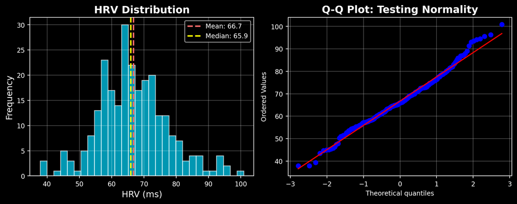

HRV distribution with normality test

```
🔬 SHAPIRO-WILK NORMALITY TEST
==================================================
Test Statistic: 0.9884
P-value:        0.0348
⚠️  HRV may not be normally distributed (p < 0.05)
```

```python
fig, axes = plt.subplots(1, 2, figsize=(10, 4))

# Histogram with KDE
axes[0].hist(df['hrv_rmssd_ms'], bins=30, alpha=0.7, color='#00D9FF', edgecolor='white')
axes[0].axvline(df['hrv_rmssd_ms'].mean(), color='#FF6B6B', linestyle='--', linewidth=2, label=f'Mean: {df["hrv_rmssd_ms"].mean():.1f}')
axes[0].axvline(df['hrv_rmssd_ms'].median(), color='yellow', linestyle='--', linewidth=2, label=f'Median: {df["hrv_rmssd_ms"].median():.1f}')
axes[0].set_xlabel('HRV (ms)', fontsize=12)
axes[0].set_ylabel('Frequency', fontsize=12)
axes[0].set_title('HRV Distribution', fontsize=14, fontweight='bold')
axes[0].legend()
axes[0].grid(alpha=0.3)

# Q-Q plot for normality check
stats.probplot(df['hrv_rmssd_ms'].dropna(), dist="norm", plot=axes[1])
axes[1].set_title('Q-Q Plot: Testing Normality', fontsize=14, fontweight='bold')
axes[1].grid(alpha=0.3)

plt.tight_layout()
plt.show()

# Normality test
statistic, p_value = stats.shapiro(df['hrv_rmssd_ms'].dropna())
print(f"\n🔬 SHAPIRO-WILK NORMALITY TEST")
print(f"{'='*50}")
print(f"Test Statistic: {statistic:.4f}")
print(f"P-value:        {p_value:.4f}")
if p_value > 0.05:
    print("✅ HRV appears normally distributed (p > 0.05)")
else:
    print("⚠️  HRV may not be normally distributed (p < 0.05)")
```

```
•   Not normal: Shapiro-Wilk p = 0.0348 → reject normality at 5%.
•   Shape: Nearly centered (mean 66.7 ≈ median 65.9) but with non-normal tails (Q-Q plot deviates at both ends). Likely mild right-skew/heavy tails.
•   Implication: Use robust stats & tests: median/IQR, Spearman (ρ) over Pearson when relating features, non-parametric tests, or bootstrap CIs.
•   For modeling: Tree models are fine. For linear models, consider transforming HRV or predictors (e.g., Box-Cox/Yeo-Johnson) and check residuals.
```

## 1.2 Feature Distributions & Outlier Detection

**Goal**: Identify data quality issues, outliers, and potential errors before modeling.

**Analyze distributions of all features**

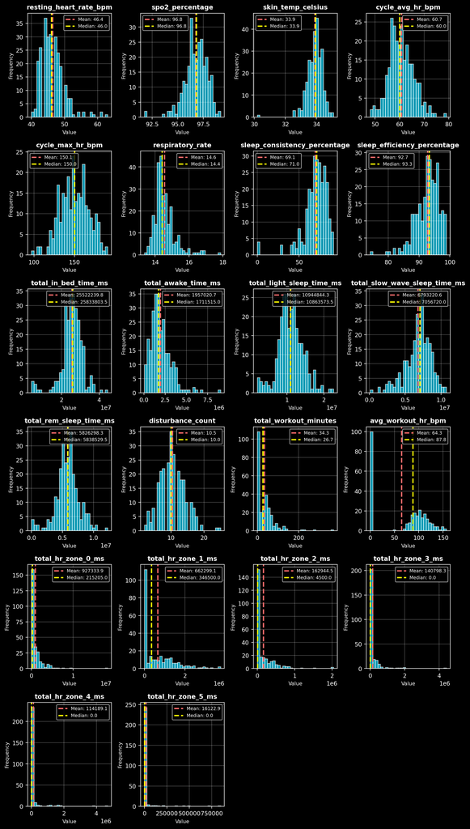

Distribution plots for all numeric features

```python
# Select numeric columns (exclude date and target)
numeric_cols = df.select_dtypes(include=[np.number]).columns.tolist()
numeric_cols.remove('hrv_rmssd_ms')  # We'll handle target separately

# Create subplots
n_cols = 4
n_rows = int(np.ceil(len(numeric_cols) / n_cols))

fig, axes = plt.subplots(n_rows, n_cols, figsize=(10, n_rows * 3))
axes = axes.flatten()

for idx, col in enumerate(numeric_cols):
    ax = axes[idx]
    data = df[col].dropna()

    # Histogram
    ax.hist(data, bins=30, alpha=0.7, color='#00D9FF', edgecolor='white')
    ax.axvline(data.mean(), color='#FF6B6B', linestyle='--', linewidth=2, label=f'Mean: {data.mean():.1f}')
    ax.axvline(data.median(), color='yellow', linestyle='--', linewidth=2, label=f'Median: {data.median():.1f}')

    ax.set_title(col, fontsize=10, fontweight='bold')
    ax.set_xlabel('Value', fontsize=8)
    ax.set_ylabel('Frequency', fontsize=8)
    ax.legend(fontsize=7)
    ax.grid(alpha=0.3)

# Hide unused subplots
for idx in range(len(numeric_cols), len(axes)):
    axes[idx].axis('off')

plt.tight_layout()
plt.show()
```

**Detect outliers using IQR method**

```python
print("\n🔍 OUTLIER DETECTION (IQR Method)")
print("="*80)

outlier_summary = []

for col in numeric_cols:
    data = df[col].dropna()

    Q1 = data.quantile(0.25)
    Q3 = data.quantile(0.75)
    IQR = Q3 - Q1

    lower_bound = Q1 - 1.5 * IQR
    upper_bound = Q3 + 1.5 * IQR

    outliers = data[(data < lower_bound) | (data > upper_bound)]

    if len(outliers) > 0:
        outlier_summary.append({
            'Feature': col,
            'Outlier Count': len(outliers),
            'Percentage': f"{len(outliers) / len(data) * 100:.2f}%",
            'Lower Bound': f"{lower_bound:.2f}",
            'Upper Bound': f"{upper_bound:.2f}",
            'Min Outlier': f"{outliers.min():.2f}",
            'Max Outlier': f"{outliers.max():.2f}"
        })

if outlier_summary:
    outlier_df = pd.DataFrame(outlier_summary)
    display(outlier_df)
else:
    print("✅ No significant outliers detected in any feature")
```

```
🔍 OUTLIER DETECTION (IQR Method)
================================================================================
```

|  | Feature | Outlier Count | Percentage | Lower Bound | Upper Bound | Min Outlier | Max Outlier |
| --- | --- | --- | --- | --- | --- | --- | --- |
| 0 | resting_heart_rate_bpm | 8 | 3.08% | 38.00 | 54.00 | 56.00 | 63.00 |
| 1 | spo2_percentage | 5 | 1.92% | 94.22 | 99.52 | 91.73 | 94.04 |
| 2 | skin_temp_celsius | 6 | 2.35% | 32.75 | 35.07 | 30.20 | 35.09 |
| 3 | cycle_avg_hr_bpm | 1 | 0.38% | 46.50 | 74.50 | 79.00 | 79.00 |
| 4 | cycle_max_hr_bpm | 1 | 0.38% | 99.50 | 199.50 | 97.00 | 97.00 |
| 5 | respiratory_rate | 14 | 5.38% | 13.29 | 15.65 | 15.66 | 17.87 |
| 6 | sleep_consistency_percentage | 8 | 3.08% | 40.88 | 101.88 | 0.00 | 40.00 |
| 7 | sleep_efficiency_percentage | 5 | 1.92% | 83.09 | 102.79 | 74.13 | 81.99 |
| 8 | total_in_bed_time_ms | 15 | 5.77% | 14505691.25 | 37005881.25 | 4123104.00 | 44443210.00 |
| 9 | total_awake_time_ms | 8 | 3.08% | -921874.38 | 4579090.62 | 4623130.00 | 9026818.00 |
| 10 | total_light_sleep_time_ms | 9 | 3.46% | 2929821.38 | 18866192.38 | 1890835.00 | 22615710.00 |
| 11 | total_slow_wave_sleep_time_ms | 11 | 4.23% | 2970606.25 | 10992252.25 | 115356.00 | 2826311.00 |
| 12 | total_rem_sleep_time_ms | 13 | 5.00% | 1938372.62 | 9737225.62 | 0.00 | 12280390.00 |
| 13 | disturbance_count | 2 | 0.77% | 0.50 | 20.50 | 24.00 | 25.00 |
| 14 | total_workout_minutes | 8 | 3.08% | -75.11 | 125.18 | 126.13 | 368.29 |
| 15 | total_hr_zone_0_ms | 20 | 7.69% | -1848634.50 | 3081057.50 | 3118525.00 | 18287159.00 |
| 16 | total_hr_zone_1_ms | 6 | 2.31% | -1730931.75 | 2884886.25 | 2908990.00 | 3762960.00 |
| 17 | total_hr_zone_2_ms | 20 | 7.69% | -338224.50 | 563707.50 | 586399.00 | 2034970.00 |
| 18 | total_hr_zone_3_ms | 41 | 15.77% | -168351.38 | 280585.62 | 287430.00 | 4417960.00 |
| 19 | total_hr_zone_4_ms | 64 | 24.62% | 0.00 | 0.00 | 961.00 | 4689960.00 |
| 20 | total_hr_zone_5_ms | 26 | 10.00% | 0.00 | 0.00 | 961.00 | 847870.00 |

**Boxplots for visual outlier inspection**

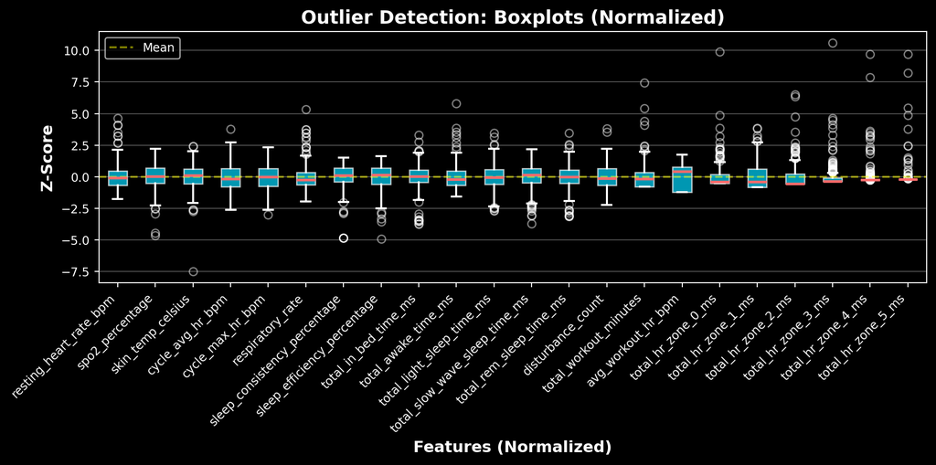

Boxplots showing outliers across all features

```python
# Normalize data for visualization (z-score)
df_normalized = df[numeric_cols].apply(lambda x: (x - x.mean()) / x.std())

fig, ax = plt.subplots(figsize=(10, 5))
bp = ax.boxplot([df_normalized[col].dropna() for col in numeric_cols],
                 labels=numeric_cols,
                 patch_artist=True,
                 showfliers=True)

# Customize boxplot colors
for patch in bp['boxes']:
    patch.set_facecolor('#00D9FF')
    patch.set_alpha(0.7)

for whisker in bp['whiskers']:
    whisker.set(color='white', linewidth=1.5)

for cap in bp['caps']:
    cap.set(color='white', linewidth=1.5)

for median in bp['medians']:
    median.set(color='#FF6B6B', linewidth=2)

for flier in bp['fliers']:
    flier.set(marker='o', color='red', alpha=0.5)

ax.set_xlabel('Features (Normalized)', fontsize=12, fontweight='bold')
ax.set_ylabel('Z-Score', fontsize=12, fontweight='bold')
ax.set_title('Outlier Detection: Boxplots (Normalized)', fontsize=14, fontweight='bold')
ax.axhline(y=0, color='yellow', linestyle='--', alpha=0.5, label='Mean')
ax.grid(axis='y', alpha=0.3)
plt.xticks(rotation=45, ha='right')
plt.legend()
plt.tight_layout()
plt.show()
```

## 1.3 Bivariate Analysis: HRV Relationships

**Goal**: Understand which features have the strongest relationships with HRV.

**Correlation matrix with HRV**

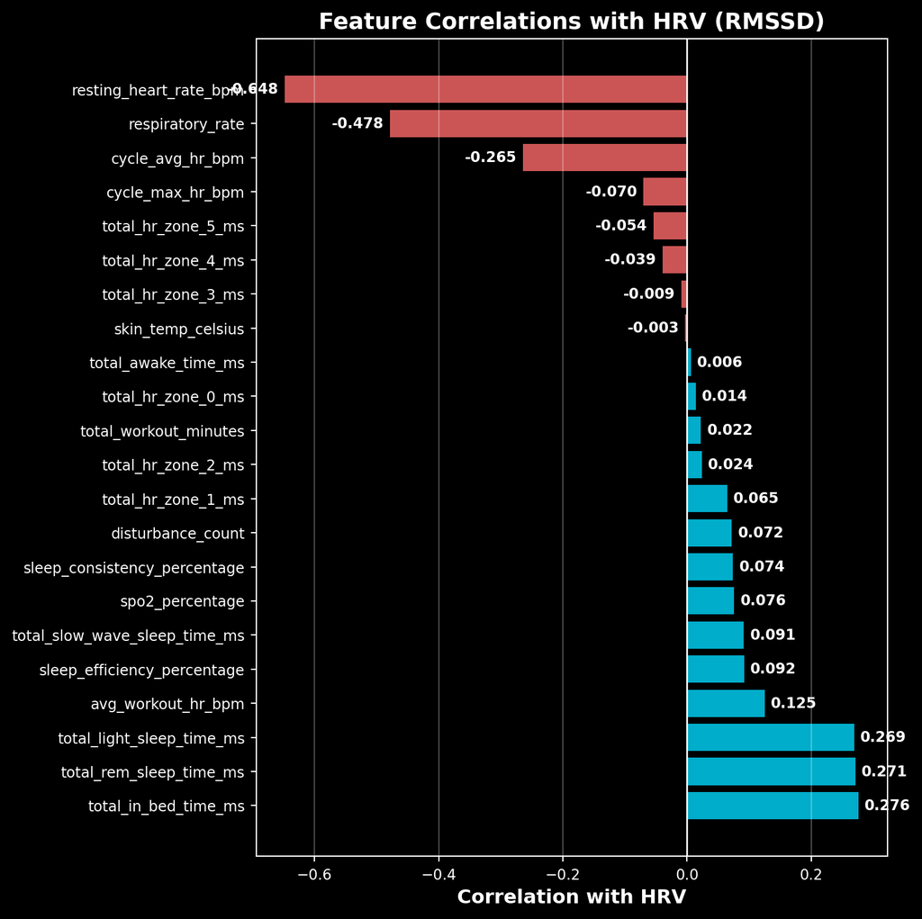

[output not shown]

```python
# Calculate correlations with HRV
correlations = df[numeric_cols + ['hrv_rmssd_ms']].corr()['hrv_rmssd_ms'].sort_values(ascending=False)

# Create horizontal bar plot
fig, ax = plt.subplots(figsize=(8, 8))

colors = ['#FF6B6B' if x < 0 else '#00D9FF' for x in correlations.values[1:]]  # Skip HRV itself
bars = ax.barh(correlations.index[1:], correlations.values[1:], color=colors, alpha=0.8)

ax.axvline(x=0, color='white', linestyle='-', linewidth=1)
ax.set_xlabel('Correlation with HRV', fontsize=12, fontweight='bold')
ax.set_title('Feature Correlations with HRV (RMSSD)', fontsize=14, fontweight='bold')
ax.grid(axis='x', alpha=0.3)

# Add value labels
for i, (bar, val) in enumerate(zip(bars, correlations.values[1:])):
    ax.text(val + 0.01 if val > 0 else val - 0.01, i, f'{val:.3f}',
            ha='left' if val > 0 else 'right', va='center', fontsize=9, fontweight='bold')

plt.tight_layout()
plt.show()

print("\n🔗 TOP 10 STRONGEST CORRELATIONS WITH HRV")
print("="*50)
# Convert to list to make it subscriptable
corr_items = list(correlations.items())
for feature, corr in corr_items[1:11]:  # Top 10, skip HRV itself
    print(f"{feature:40s}: {corr:>7.3f}")
```

**Scatter plots for key features vs HRV**

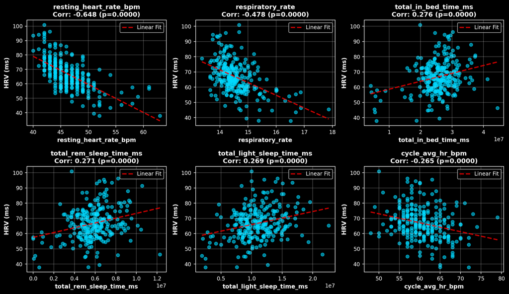

Bivariate relationships: Key features vs HRV

```python
# Select top 6 correlated features (absolute value)
top_features = correlations.abs().sort_values(ascending=False).index[1:7].tolist()

fig, axes = plt.subplots(2, 3, figsize=(12, 7))
axes = axes.flatten()

for idx, feature in enumerate(top_features):
    ax = axes[idx]

    # Scatter plot
    ax.scatter(df[feature], df['hrv_rmssd_ms'], alpha=0.6, s=30, color='#00D9FF')

    # Add regression line
    mask = df[[feature, 'hrv_rmssd_ms']].notna().all(axis=1)
    if mask.sum() > 1:
        z = np.polyfit(df.loc[mask, feature], df.loc[mask, 'hrv_rmssd_ms'], 1)
        p = np.poly1d(z)
        ax.plot(df.loc[mask, feature].sort_values(),
                p(df.loc[mask, feature].sort_values()),
                "r--", linewidth=2, alpha=0.8, label=f'Linear Fit')

    # Calculate correlation
    corr, p_val = pearsonr(df[feature].dropna(), df['hrv_rmssd_ms'].dropna())

    ax.set_xlabel(feature, fontsize=10, fontweight='bold')
    ax.set_ylabel('HRV (ms)', fontsize=10, fontweight='bold')
    ax.set_title(f'{feature}\nCorr: {corr:.3f} (p={p_val:.4f})', fontsize=11, fontweight='bold')
    ax.grid(alpha=0.3)
    ax.legend()

plt.tight_layout()
plt.show()
```

**Analyze relationship between sleep stages and HRV**

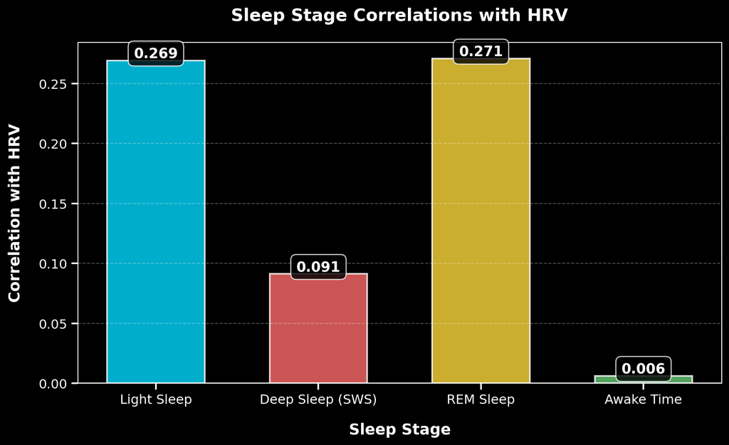

Sleep stage impact on HRV

```python
# Convert sleep times from ms to hours
sleep_cols = ['total_light_sleep_time_ms', 'total_slow_wave_sleep_time_ms',
              'total_rem_sleep_time_ms', 'total_awake_time_ms']

df_sleep = df.copy()
for col in sleep_cols:
    df_sleep[col.replace('_ms', '_hrs')] = df_sleep[col] / (1000 * 60 * 60)

# Create grouped bar plot with improved labels
sleep_stage_corrs = []
# Use cleaner, more readable labels
label_mapping = {
    'total_light_sleep_time_ms': 'Light Sleep',
    'total_slow_wave_sleep_time_ms': 'Deep Sleep (SWS)',
    'total_rem_sleep_time_ms': 'REM Sleep',
    'total_awake_time_ms': 'Awake Time'
}

for col in sleep_cols:
    col_hrs = col.replace('_ms', '_hrs')
    corr, _ = pearsonr(df_sleep[col_hrs].dropna(), df_sleep['hrv_rmssd_ms'].dropna())
    sleep_stage_corrs.append({
        'Sleep Stage': label_mapping[col],
        'Correlation': corr
    })

sleep_corr_df = pd.DataFrame(sleep_stage_corrs)

# Create figure with more padding
fig, ax = plt.subplots(figsize=(10, 5.5))
bars = ax.bar(sleep_corr_df['Sleep Stage'], sleep_corr_df['Correlation'],
              color=['#00D9FF', '#FF6B6B', '#FFD93D', '#6BCB77'],
              alpha=0.8, width=0.6, edgecolor='white', linewidth=1.5)

ax.axhline(y=0, color='white', linestyle='-', linewidth=1.5, alpha=0.5)
ax.set_ylabel('Correlation with HRV', fontsize=14, fontweight='bold', labelpad=15)
ax.set_xlabel('Sleep Stage', fontsize=14, fontweight='bold', labelpad=15)
ax.set_title('Sleep Stage Correlations with HRV', fontsize=16, fontweight='bold', pad=20)
ax.grid(axis='y', alpha=0.3, linestyle='--')

# Improved value labels - positioned directly on top of bars
for bar, val in zip(bars, sleep_corr_df['Correlation']):
    height = bar.get_height()
    # Position labels just above the top of each bar
    ax.text(bar.get_x() + bar.get_width()/2.,
            height,  # Exactly at the bar height
            f'{val:.3f}',
            ha='center',
            va='bottom',  # Align bottom of text with top of bar
            fontsize=13,
            fontweight='bold',
            color='white',
            bbox=dict(boxstyle='round,pad=0.4', facecolor='black', alpha=0.8, edgecolor='white', linewidth=1))

# Improved x-axis labels - no rotation needed with cleaner names
ax.tick_params(axis='both', which='major', labelsize=12, length=6, width=1.5)
plt.xticks(rotation=0)  # Horizontal labels for better readability

# Add more padding around the plot
plt.tight_layout(pad=2.0)  # Increased padding
plt.subplots_adjust(left=0.12, right=0.95, top=0.92, bottom=0.12)

plt.show()
```

```
•   REM and Light sleep matter most for your next-morning HRV: r ≈ 0.27 each → about 7% of HRV variance individually (0.27²).
•   Slow-wave (deep) sleep shows a weak link (r ≈ 0.09, <1% variance).
•   Awake time is essentially uninformative (r ≈ 0.006).
```

# Key Insights from EDA

**Generate summary of key findings**

```python
print("\n" + "="*80)
print("📊 EXPLORATORY DATA ANALYSIS SUMMARY")
print("="*80)

print(f"\n1️⃣  DATASET OVERVIEW")
print(f"   • Total observations: {len(df)} days")
print(f"   • Date range: {(df['cycle_date'].max() - df['cycle_date'].min()).days} days")
print(f"   • Missing data: {df.isnull().sum().sum()} total missing values")

print(f"\n2️⃣  HRV CHARACTERISTICS")
print(f"   • Mean HRV: {df['hrv_rmssd_ms'].mean():.1f} ms")
print(f"   • Coefficient of Variation: {(df['hrv_rmssd_ms'].std() / df['hrv_rmssd_ms'].mean() * 100):.1f}%")
print(f"   • Distribution: {'Normal' if stats.shapiro(df['hrv_rmssd_ms'].dropna())[1] > 0.05 else 'Non-normal'}")

print(f"\n3️⃣  TOP POSITIVE CORRELATIONS (Higher → Higher HRV)")
top_pos = correlations[correlations > 0].sort_values(ascending=False)[1:4]
for feature, corr in top_pos.items():
    print(f"   • {feature}: {corr:.3f}")

print(f"\n4️⃣  TOP NEGATIVE CORRELATIONS (Higher → Lower HRV)")
top_neg = correlations[correlations < 0].sort_values()[0:3]
for feature, corr in top_neg.items():
    print(f"   • {feature}: {corr:.3f}")

print(f"\n5️⃣  DATA QUALITY")
outlier_count = sum([len(df[col][(df[col] < df[col].quantile(0.25) - 1.5 * (df[col].quantile(0.75) - df[col].quantile(0.25))) |
                                   (df[col] > df[col].quantile(0.75) + 1.5 * (df[col].quantile(0.75) - df[col].quantile(0.25)))])
                      for col in numeric_cols])
print(f"   • Total outliers detected: {outlier_count}")
print(f"   • Features with >10% missing: {len(missing_df[missing_df['Percentage'] > 10])}")

print("\n" + "="*80)
print("✅ Phase 1 Complete: Ready for Feature Engineering & Modeling")
print("="*80)
```

```
================================================================================
📊 EXPLORATORY DATA ANALYSIS SUMMARY
================================================================================

1️⃣  DATASET OVERVIEW
   • Total observations: 260 days
   • Date range: 267 days
   • Missing data: 5 total missing values

2️⃣  HRV CHARACTERISTICS
   • Mean HRV: 66.7 ms
   • Coefficient of Variation: 16.2%
   • Distribution: Non-normal

3️⃣  TOP POSITIVE CORRELATIONS (Higher → Higher HRV)
   • total_in_bed_time_ms: 0.276
   • total_rem_sleep_time_ms: 0.271
   • total_light_sleep_time_ms: 0.269

4️⃣  TOP NEGATIVE CORRELATIONS (Higher → Lower HRV)
   • resting_heart_rate_bpm: -0.648
   • respiratory_rate: -0.478
   • cycle_avg_hr_bpm: -0.265

5️⃣  DATA QUALITY
   • Total outliers detected: 291
   • Features with >10% missing: 0

================================================================================
✅ Phase 1 Complete: Ready for Feature Engineering & Modeling
================================================================================
```

# Phase 2: Data Preprocessing & Feature Engineering

## 2.1 Missing Data Imputation

**Critical First Step**: Handle missing values BEFORE creating any derived features. Lagged and rolling window calculations will fail or produce incorrect results with NULL values.

**Impute missing values with appropriate strategies**

```python
# Store original dataset for comparison
df_original = df.copy()

print("🔧 MISSING DATA IMPUTATION")
print("="*80)

# Check missing data before imputation
missing_before = df.isnull().sum()
print("\n📊 Missing values BEFORE imputation:")
print(missing_before[missing_before > 0])

# Imputation Strategy:
# - skin_temp_celsius: Use MEDIAN (robust to outliers)
# - Other numeric features: Use MEDIAN (safer than mean for skewed distributions)

numeric_cols_to_impute = df.select_dtypes(include=[np.number]).columns.tolist()

for col in numeric_cols_to_impute:
    if df[col].isnull().sum() > 0:
        median_value = df[col].median()
        missing_n = df[col].isna().sum()
        df[col] = df[col].fillna(median_value)
        print(f"✅ {col}: Filled {missing_n} missing values with median ({median_value:.2f})")

# Verify no missing values remain
missing_after = df.isnull().sum()
print(f"\n✅ Total missing values AFTER imputation: {missing_after.sum()}")

if missing_after.sum() == 0:
    print("🎉 All missing data successfully imputed!")
else:
    print("⚠️  Some missing values remain:")
    print(missing_after[missing_after > 0])
```

```
🔧 MISSING DATA IMPUTATION
================================================================================

📊 Missing values BEFORE imputation:
skin_temp_celsius    5
dtype: int64
✅ skin_temp_celsius: Filled 5 missing values with median (33.94)

✅ Total missing values AFTER imputation: 0
🎉 All missing data successfully imputed!
```

## 2.2 Feature Engineering (Time-Based Features)

**Important**: Engineer features from the ORIGINAL, untransformed data. This keeps features in human-interpretable units (minutes, bpm, etc.).

**Create lagged features and rolling windows for time-series analysis**

```python
print("\n🔨 FEATURE ENGINEERING")
print("="*80)

# Store original dataset for comparison BEFORE feature engineering
df_original = df.copy()

# Sort by date to ensure correct time-series order
df = df.sort_values('cycle_date').reset_index(drop=True)
# Ensure cycle_date is true datetime for .dt operations (defensive)
from pandas.api.types import is_datetime64_any_dtype
if not is_datetime64_any_dtype(df['cycle_date']):
    df['cycle_date'] = pd.to_datetime(df['cycle_date'], errors='coerce')

# ============================================================================
# LAG FEATURES: Yesterday's values affecting today's HRV
# ============================================================================

lag_features = [
    'total_workout_minutes',
    'avg_workout_hr_bpm',
    'resting_heart_rate_bpm',
    'sleep_efficiency_percentage',
    'total_rem_sleep_time_ms',
    'total_slow_wave_sleep_time_ms'
]

print("\n📅 Creating LAG-1 Features (Previous Day):")
for feature in lag_features:
    lag_col_name = f"{feature}_lag1"
    df[lag_col_name] = df[feature].shift(1)
    print(f"   ✅ {lag_col_name}")

# ============================================================================
# ROLLING WINDOW FEATURES: Multi-day trends and patterns
# ============================================================================

rolling_features = [
    ('total_workout_minutes', 7, 'mean'),
    ('total_workout_minutes', 7, 'sum'),
    ('resting_heart_rate_bpm', 7, 'mean'),
    ('sleep_efficiency_percentage', 7, 'mean'),
    ('hrv_rmssd_ms', 7, 'std'),  # HRV variability over 7 days
]

print("\n📊 Creating ROLLING WINDOW Features:")
for feature, window, agg_func in rolling_features:
    col_name = f"{feature}_rolling{window}d_{agg_func}"

    if agg_func == 'mean':
        df[col_name] = df[feature].rolling(window=window, min_periods=1).mean()
    elif agg_func == 'sum':
        df[col_name] = df[feature].rolling(window=window, min_periods=1).sum()
    elif agg_func == 'std':
        df[col_name] = df[feature].rolling(window=window, min_periods=1).std()

    print(f"   ✅ {col_name}")

# ============================================================================
# CUMULATIVE TRAINING LOAD: Running total of workout time
# ============================================================================

print("\n💪 Creating CUMULATIVE TRAINING LOAD:")
df['cumulative_workout_minutes'] = df['total_workout_minutes'].cumsum()
print("   ✅ cumulative_workout_minutes")

# ============================================================================
# INTERACTION FEATURES: Combined effects
# ============================================================================

print("\n🔗 Creating INTERACTION Features:")

# Sleep quality score (normalized composite)
df['sleep_quality_score'] = (
    (df['sleep_efficiency_percentage'] / 100) * 0.4 +
    (df['total_rem_sleep_time_ms'] / df['total_rem_sleep_time_ms'].max()) * 0.3 +
    (df['total_slow_wave_sleep_time_ms'] / df['total_slow_wave_sleep_time_ms'].max()) * 0.3
)
print("   ✅ sleep_quality_score (composite)")


# Workout intensity index (HR zones weighted)
df['workout_intensity_index'] = (
    df['total_hr_zone_0_ms'] * 0.5 +
    df['total_hr_zone_1_ms'] * 1.0 +
    df['total_hr_zone_2_ms'] * 1.5 +
    df['total_hr_zone_3_ms'] * 2.0 +
    df['total_hr_zone_4_ms'] * 2.5 +
    df['total_hr_zone_5_ms'] * 3.0
) / 1000  # Convert ms to seconds
print("   ✅ workout_intensity_index (weighted HR zones)")

# ============================================================================
# ADVANCED PHYSIOLOGICAL FEATURES
# ============================================================================

print("\n🧠 Creating ADVANCED PHYSIOLOGICAL FEATURES:")

# 1. Exponentially Weighted Workout Intensity
print("   ➕ Exponentially Weighted Workout Intensity")
df['workout_intensity_exp'] = (
    df['total_hr_zone_1_ms'] * (1.2**1) +
    df['total_hr_zone_2_ms'] * (1.2**2) +
    df['total_hr_zone_3_ms'] * (1.2**3) +
    df['total_hr_zone_4_ms'] * (1.2**4) +
    df['total_hr_zone_5_ms'] * (1.2**5)
)

# 2. Proportional Sleep Stages
print("   ➕ Proportional Sleep Stage Features")
df['total_sleep_time_ms'] = df['total_in_bed_time_ms'] - df['total_awake_time_ms']
df['rem_sleep_pct'] = df['total_rem_sleep_time_ms'] / df['total_sleep_time_ms']
df['sws_sleep_pct'] = df['total_slow_wave_sleep_time_ms'] / df['total_sleep_time_ms']

# 3. Rate of Change Features: Deviation from Rolling Mean
print("   ➕ Deviation from Rolling Mean Features")
if 'resting_heart_rate_bpm_rolling7d_mean' in df.columns:
    df['rhr_deviation_from_7d_mean'] = df['resting_heart_rate_bpm'] - df['resting_heart_rate_bpm_rolling7d_mean']
else:
    df['rhr_deviation_from_7d_mean'] = np.nan

# 4. Strain vs Recovery Balance Score
print("   ➕ Strain vs Recovery Balance Features")
from sklearn.preprocessing import StandardScaler
scaler = StandardScaler()
try:
    df[['sleep_quality_score_scaled', 'workout_intensity_exp_scaled']] = scaler.fit_transform(
        df[['sleep_quality_score', 'workout_intensity_exp']]
    )
    df['strain_recovery_balance'] = df['sleep_quality_score_scaled'] - df['workout_intensity_exp_scaled']
    df['strain_recovery_balance_lag1'] = df['strain_recovery_balance'].shift(1)
except Exception as e:
    print(f"⚠️  Could not compute strain_recovery_balance: {e}")

# 5. Day-of-Week & Weekend Flag
print("   ➕ Day-of-Week and Weekend Flags")
df['day_of_week'] = df['cycle_date'].dt.dayofweek
df['is_weekend'] = df['day_of_week'].isin([5, 6]).astype(int)

print("✅ Advanced physiological features successfully added.")

# Display summary of new features
new_features = [col for col in df.columns if col not in df_original.columns]
print(f"\n✅ Total new features created: {len(new_features)}")
print(f"📊 Dataset shape: {df.shape[0]} rows × {df.shape[1]} columns (was {df_original.shape[1]})")
```

```
🔨 FEATURE ENGINEERING
================================================================================

📅 Creating LAG-1 Features (Previous Day):
   ✅ total_workout_minutes_lag1
   ✅ avg_workout_hr_bpm_lag1
   ✅ resting_heart_rate_bpm_lag1
   ✅ sleep_efficiency_percentage_lag1
   ✅ total_rem_sleep_time_ms_lag1
   ✅ total_slow_wave_sleep_time_ms_lag1

📊 Creating ROLLING WINDOW Features:
   ✅ total_workout_minutes_rolling7d_mean
   ✅ total_workout_minutes_rolling7d_sum
   ✅ resting_heart_rate_bpm_rolling7d_mean
   ✅ sleep_efficiency_percentage_rolling7d_mean
   ✅ hrv_rmssd_ms_rolling7d_std

💪 Creating CUMULATIVE TRAINING LOAD:
   ✅ cumulative_workout_minutes

🔗 Creating INTERACTION Features:
   ✅ sleep_quality_score (composite)
   ✅ workout_intensity_index (weighted HR zones)

🧠 Creating ADVANCED PHYSIOLOGICAL FEATURES:
   ➕ Exponentially Weighted Workout Intensity
   ➕ Proportional Sleep Stage Features
   ➕ Deviation from Rolling Mean Features
   ➕ Strain vs Recovery Balance Features
   ➕ Day-of-Week and Weekend Flags
✅ Advanced physiological features successfully added.

✅ Total new features created: 25
📊 Dataset shape: 260 rows × 49 columns (was 24)
```

**Display summary of engineered features**

```python
print("\n📋 ENGINEERED FEATURES SUMMARY")
print("="*80)

feature_summary = []

# Lag features
lag_cols = [col for col in df.columns if '_lag1' in col]
feature_summary.append({'Category': 'Lag Features (Day -1)', 'Count': len(lag_cols), 'Examples': ', '.join(lag_cols[:3])})

# Rolling features
rolling_cols = [col for col in df.columns if 'rolling' in col]
feature_summary.append({'Category': 'Rolling Window (7-day)', 'Count': len(rolling_cols), 'Examples': ', '.join(rolling_cols[:3])})

# Cumulative features
cumulative_cols = [col for col in df.columns if 'cumulative' in col]
feature_summary.append({'Category': 'Cumulative Features', 'Count': len(cumulative_cols), 'Examples': ', '.join(cumulative_cols)})

# Interaction features
interaction_cols = ['sleep_quality_score', 'workout_intensity_index']
feature_summary.append({'Category': 'Interaction Features', 'Count': len(interaction_cols), 'Examples': ', '.join(interaction_cols)})

feature_summary_df = pd.DataFrame(feature_summary)
display(feature_summary_df)
```

```
📋 ENGINEERED FEATURES SUMMARY
================================================================================
```

|  | Category | Count | Examples |
| --- | --- | --- | --- |
| 0 | Lag Features (Day -1) | 7 | total_workout_minutes_lag1, avg_workout_hr_bpm... |
| 1 | Rolling Window (7-day) | 5 | total_workout_minutes_rolling7d_mean, total_wo... |
| 2 | Cumulative Features | 1 | cumulative_workout_minutes |
| 3 | Interaction Features | 2 | sleep_quality_score, workout_intensity_index |

## 2.3 Train-Test Split (Time-Series Aware)

**Critical**: Split data BEFORE any transformations that learn from the data (scaling, normalization). Use chronological split to prevent data leakage.

**Chronological split for time-series validation**

```python
print("\n✂️  TRAIN-TEST SPLIT (Chronological)")
print("="*80)

# Remove rows with NaN values created by lagging (first row will have NaN lags)
# Also ensure cycle_date is datetime for .dt operations
df['cycle_date'] = pd.to_datetime(df['cycle_date'], errors='coerce')
df_clean = df.dropna()

# Calculate 80/20 split point
split_index = int(len(df_clean) * 0.8)
# Ensure we have a Timestamp for plotting and a date for filtering
split_date_ts = pd.to_datetime(df_clean.iloc[split_index]['cycle_date'])
split_date_date = split_date_ts.date()

# Ensure cycle_date is datetime and compare on .dt.date to avoid dtype issues
train_df = df_clean[df_clean['cycle_date'].dt.date < split_date_date].copy()
test_df = df_clean[df_clean['cycle_date'].dt.date >= split_date_date].copy()

print(f"📊 DATASET SPLIT:")
print(f"   Training Set:   {len(train_df)} days ({len(train_df)/len(df_clean)*100:.1f}%)")
print(f"   Test Set:       {len(test_df)} days ({len(test_df)/len(df_clean)*100:.1f}%)")
print(f"   Split Date:     {split_date_ts}")
print(f"   Train Range:    {train_df['cycle_date'].min()} → {train_df['cycle_date'].max()}")
print(f"   Test Range:     {test_df['cycle_date'].min()} → {test_df['cycle_date'].max()}")

# Verify no data leakage
if train_df['cycle_date'].max() >= test_df['cycle_date'].min():
    print("⚠️  WARNING: Potential data leakage detected!")
else:
    print("✅ No data leakage: Training data ends before test data begins")

# Visualize split
fig = go.Figure()

fig.add_trace(go.Scatter(
    x=train_df['cycle_date'],
    y=train_df['hrv_rmssd_ms'],
    mode='markers',
    name='Training Data',
    marker=dict(color='#00D9FF', size=6, opacity=0.7),
))

fig.add_trace(go.Scatter(
    x=test_df['cycle_date'],
    y=test_df['hrv_rmssd_ms'],
    mode='markers',
    name='Test Data',
    marker=dict(color='#FF6B6B', size=6, opacity=0.7),
))

fig.add_vline(
    x=split_date_ts,
    line_dash="dash",
    line_color="yellow",
)

fig.add_annotation(
    x=split_date_ts, y=1, yref="paper",
    text="Train/Test Split",
    showarrow=False, yanchor="bottom"
)

fig.update_layout(
    title="Train-Test Split: Chronological Separation",
    xaxis_title="Date",
    yaxis_title="HRV (ms)",
    template="plotly_dark",
    height=500
)

fig.show()
```

```
✂️  TRAIN-TEST SPLIT (Chronological)
================================================================================
📊 DATASET SPLIT:
   Training Set:   207 days (79.9%)
   Test Set:       52 days (20.1%)
   Split Date:     2025-08-18 00:00:00
   Train Range:    2025-01-15 00:00:00 → 2025-08-17 00:00:00
   Test Range:     2025-08-18 00:00:00 → 2025-10-08 00:00:00
✅ No data leakage: Training data ends before test data begins
```

[interactive chart not shown]

### 🧩 Interpretation: Train–Test Split

- **Purpose**: The chart shows a chronological split of HRV data into training (blue) and test (red).
- **What It Means**: The **yellow dashed line** is the cutoff; left = train, right = test. This prevents temporal leakage and mirrors real forecasting.
- **Observations**: Test-period HRV is slightly higher/less variable (recent upward trend), but ranges overlap (~40–100 ms), so distribution shift is modest.
- **Why It Matters**: Validates that evaluation is truly out-of-sample in time.

**Final verification of preprocessing pipeline**

```python
print("\n✅ PREPROCESSING PIPELINE COMPLETE")
print("="*80)

print(f"\n1️⃣  Missing Data:")
print(f"   • Original missing values: {df_original.isnull().sum().sum()}")
print(f"   • After imputation: {df.isnull().sum().sum()}")

print(f"\n2️⃣  Feature Engineering:")
print(f"   • Original features: {df_original.shape[1]}")
print(f"   • Engineered features: {df.shape[1] - df_original.shape[1]}")
print(f"   • Total features: {df.shape[1]}")

print(f"\n3️⃣  Data Split:")
print(f"   • Training samples: {len(train_df)}")
print(f"   • Test samples: {len(test_df)}")
print(f"   • No data leakage: ✅")

print(f"\n📈 Ready for modeling with {df.shape[1]} features!")
```

[output not shown]

## 2.4 Data Transformation & Scaling

**Strategy**: Create TWO separate datasets optimized for different model families: 1. **Tree-based models (XGBoost, Random Forest)**: Use raw data (no transformations needed) 2. **Linear models (Lasso, Ridge)**: Apply log transformations to highly skewed features

**Prepare datasets for tree-based and linear models**

```python
print("\n🔀 DATA TRANSFORMATION STRATEGY")
print("="*80)

# ============================================================================
# DATASET 1: For Tree-Based Models (XGBoost, Random Forest)
# ============================================================================

print("\n🌳 DATASET 1: Tree-Based Models (No Transformation)")
print("-" * 80)

# Tree models are robust to skewed distributions - use raw features
train_tree = train_df.copy()
test_tree = test_df.copy()

print(f"✅ Training set: {train_tree.shape}")
print(f"✅ Test set:     {test_tree.shape}")
print("📌 Strategy: Use raw features (tree models handle skewness naturally)")

# ============================================================================
# DATASET 2: For Linear Models (Lasso, Ridge, ElasticNet)
# ============================================================================

print("\n📈 DATASET 2: Linear Models (Log Transformation)")
print("-" * 80)

# Identify highly skewed features for transformation
skewed_features = [
    'total_workout_minutes',
    'total_hr_zone_0_ms',
    'total_hr_zone_1_ms',
    'total_hr_zone_2_ms',
    'total_hr_zone_3_ms',
    'total_hr_zone_4_ms',
    'total_hr_zone_5_ms',
    'workout_intensity_index',
    'total_workout_minutes_rolling7d_sum',
    'cumulative_workout_minutes'
]

# Create copies for linear models
train_linear = train_df.copy()
test_linear = test_df.copy()

print("\n🔢 Applying log(x + 1) transformation to skewed features:")
for feature in skewed_features:
    if feature in train_linear.columns:
        # Apply log(x + 1) transformation
        train_linear[f'{feature}_log'] = np.log1p(train_linear[feature])
        test_linear[f'{feature}_log'] = np.log1p(test_linear[feature])

        # Drop original feature (keep only transformed version)
        train_linear = train_linear.drop(columns=[feature])
        test_linear = test_linear.drop(columns=[feature])

        print(f"   ✅ {feature} → {feature}_log")

print(f"\n✅ Training set: {train_linear.shape}")
print(f"✅ Test set:     {test_linear.shape}")
print("📌 Strategy: Log-transform skewed workout features for linear assumptions")

# ============================================================================
# Visualize Transformation Effect
# ============================================================================

print("\n📊 Visualizing transformation effect on key features...")
```

```
🔀 DATA TRANSFORMATION STRATEGY
================================================================================

🌳 DATASET 1: Tree-Based Models (No Transformation)
--------------------------------------------------------------------------------
✅ Training set: (207, 49)
✅ Test set:     (52, 49)
📌 Strategy: Use raw features (tree models handle skewness naturally)

📈 DATASET 2: Linear Models (Log Transformation)
--------------------------------------------------------------------------------

🔢 Applying log(x + 1) transformation to skewed features:
   ✅ total_workout_minutes → total_workout_minutes_log
   ✅ total_hr_zone_0_ms → total_hr_zone_0_ms_log
   ✅ total_hr_zone_1_ms → total_hr_zone_1_ms_log
   ✅ total_hr_zone_2_ms → total_hr_zone_2_ms_log
   ✅ total_hr_zone_3_ms → total_hr_zone_3_ms_log
   ✅ total_hr_zone_4_ms → total_hr_zone_4_ms_log
   ✅ total_hr_zone_5_ms → total_hr_zone_5_ms_log
   ✅ workout_intensity_index → workout_intensity_index_log
   ✅ total_workout_minutes_rolling7d_sum → total_workout_minutes_rolling7d_sum_log
   ✅ cumulative_workout_minutes → cumulative_workout_minutes_log

✅ Training set: (207, 49)
✅ Test set:     (52, 49)
📌 Strategy: Log-transform skewed workout features for linear assumptions

📊 Visualizing transformation effect on key features...
```

**Compare distributions before/after log transformation**

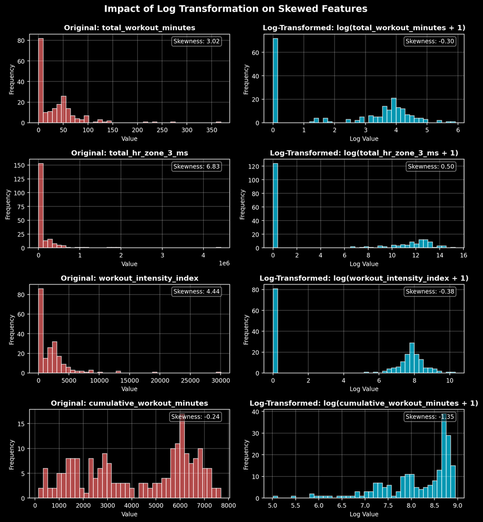

Effect of log transformation on skewed features

[output not shown]

```python
# Select 4 key features to visualize
features_to_visualize = [
    'total_workout_minutes',
    'total_hr_zone_3_ms',
    'workout_intensity_index',
    'cumulative_workout_minutes'
]

fig, axes = plt.subplots(4, 2, figsize=(10, 11))

for idx, feature in enumerate(features_to_visualize):
    if feature not in train_df.columns:
        continue

    # Left column: Original distribution
    ax_orig = axes[idx, 0]
    data_orig = train_df[feature].dropna()
    ax_orig.hist(data_orig, bins=40, alpha=0.7, color='#FF6B6B', edgecolor='white')
    ax_orig.set_title(f'Original: {feature}', fontsize=11, fontweight='bold')
    ax_orig.set_xlabel('Value', fontsize=9)
    ax_orig.set_ylabel('Frequency', fontsize=9)
    ax_orig.grid(alpha=0.3)

    # Add skewness annotation
    skewness = data_orig.skew()
    ax_orig.text(0.95, 0.95, f'Skewness: {skewness:.2f}',
                 transform=ax_orig.transAxes, ha='right', va='top',
                 bbox=dict(boxstyle='round', facecolor='black', alpha=0.5),
                 fontsize=9, color='white')

    # Right column: Log-transformed distribution
    ax_log = axes[idx, 1]
    data_log = np.log1p(data_orig)
    ax_log.hist(data_log, bins=40, alpha=0.7, color='#00D9FF', edgecolor='white')
    ax_log.set_title(f'Log-Transformed: log({feature} + 1)', fontsize=11, fontweight='bold')
    ax_log.set_xlabel('Log Value', fontsize=9)
    ax_log.set_ylabel('Frequency', fontsize=9)
    ax_log.grid(alpha=0.3)

    # Add skewness annotation
    skewness_log = data_log.skew()
    ax_log.text(0.95, 0.95, f'Skewness: {skewness_log:.2f}',
                transform=ax_log.transAxes, ha='right', va='top',
                bbox=dict(boxstyle='round', facecolor='black', alpha=0.5),
                fontsize=9, color='white')

plt.suptitle('Impact of Log Transformation on Skewed Features',
             fontsize=14, fontweight='bold', y=0.995)
plt.tight_layout()
plt.show()

print("\n💡 TRANSFORMATION INSIGHTS:")
print("   • Original features show heavy right-skew (long tail of high values)")
print("   • Log transformation normalizes distributions for linear model assumptions")
print("   • Tree models don't need this - they handle skewness naturally")
```

**Standardize features for linear models**